# Beyond the Primary Outcome: Mediation and Predictive Insights from clinical trials

AusTriM presentation April, 2025

Dr Kristy Robledo

NHMRC CTC, The University of Sydney

# Overview of today’s talk

- Prediction versus inference
- What is prediction modelling?
- Prediction example: Risk score model
- Inference example: Mediation analysis
- The future…

## **Inference** (explaining) versus **Prediction** (future)

**Explaining**

- collect data from given sample (e.g. clinical trial)
- apply models to test hypotheses (explain relationships)
- inference can be causal

**Prediction**

- apply a model to data
- predicting new or future observations

**Explanatory** **predictive**

[Shmueli (2010) To Explain or to Predict? Statistical Science. 25(3):289-310. DOI: 10.1214/10-STS330](https://doi.org/10.1214/10-STS330)

# What is prediction modelling?

- prognostic modelling
- risk prediction modelling
- risk calculators

## Diagnostic vs Prognostic models

**Diagnostic**

- Predicts the presence or absence of a disease or condition
- e.g. breast cancer detection

**Prognostic**

- Prediction of a disease course (including treatment)
- eg. probability of CVD events for a patient with diabetes

## Pipeline for translation of a clinical trial into practice

**Individual** absolute risk (current treatment)

**Risk prediction model**

**x**

Relative risk reduction (new treatment)

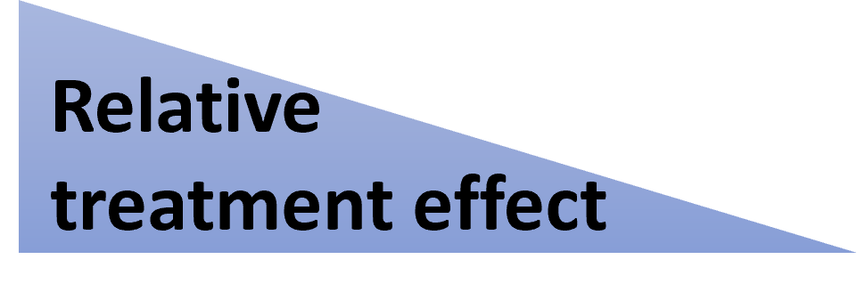

**Predictive Biomarker** (clinical trial)

**=**

**Personalised** absolute risk reduction

size of benefit

Decision for practice/policy

# Methods for developing predictive models

## Current reporting guidelines

[figure not shown]

https://www.bmj.com/content/385/bmj-2023-078378.

# Prediction example: T4DM risk score model

## Development cohort: T4DM trial

- males aged 50 to 74 years,
- waist circumference ≥95 cm,
- impaired glucose tolerance or newly diagnosed type 2 diabetes,
- fasting testosterone ≤14 nmol/L

**Primary outcome:** Diabetes at two years, as measured by 2-hour glucose by OGTT $\ge$ 11.1mmol/L

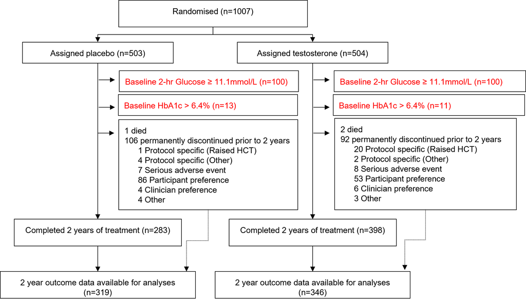

Wittert G, Bracken K, Robledo KP, et al. Testosterone treatment to prevent or revert type 2 diabetes in men enrolled in a lifestyle programme (T4DM): A randomised, double-blind, placebo-controlled, 2-year, phase 3b trial. The Lancet Diabetes & Endocrinology 2021;9:32–45. https://doi.org/10.1016/S2213-8587(20)30367-3

## Sample size assumptions

- 665 participants available for development model
- overall event rate of 10% at 2 years
- C-statistic of ~0.78 (based on AUSDIAB)
- Cox-Snell R-squared value of 0.2 (conservative anticipated model performance reflecting signal:noise, with low being more noise)

*16 risk factors can be considered before overfitting becomes a concern*

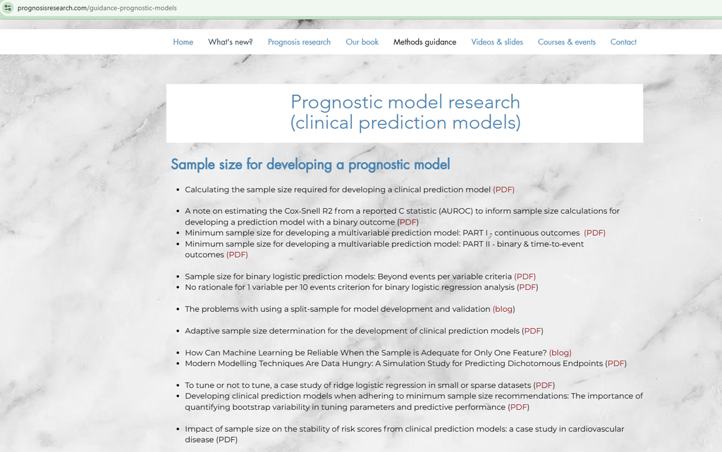

Riley RD et al. Calculating the sample size required for developing a clinical prediction model. BMJ 2020. https://doi.org/10.1136/bmj.m441.

Further guidance: https://www.prognosisresearch.com/guidance-prognostic-models

## Preliminary step: Data completeness

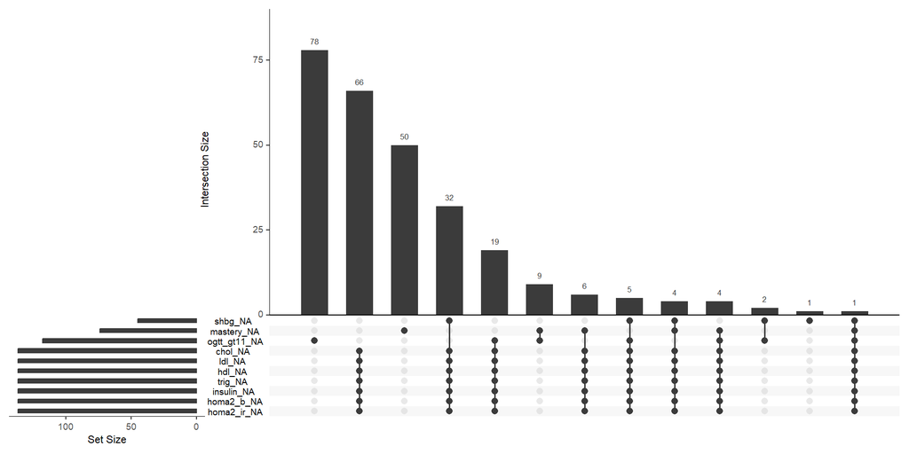

Intersection of missingness over risk factors in the 783 participants (all eligible cohort)

naniar::gg__miss_upset() function to plot the missingness using an upset plot

## Step one: Univariate analyses

[output not shown]

[output cut: 60 more lines]

Abbreviations: CI = Confidence Interval, OR = Odds Ratio

<sup>1</sup> n (%); Median (Q1, Q3)

gtsummary::tbl_summary() function to summarise the data, combined with gtsummary::tbl_uvregression() to run univariate logistic regression models, merged together using gtsummary::tbl_merge()

## Step two: 33 to 16 risk factors

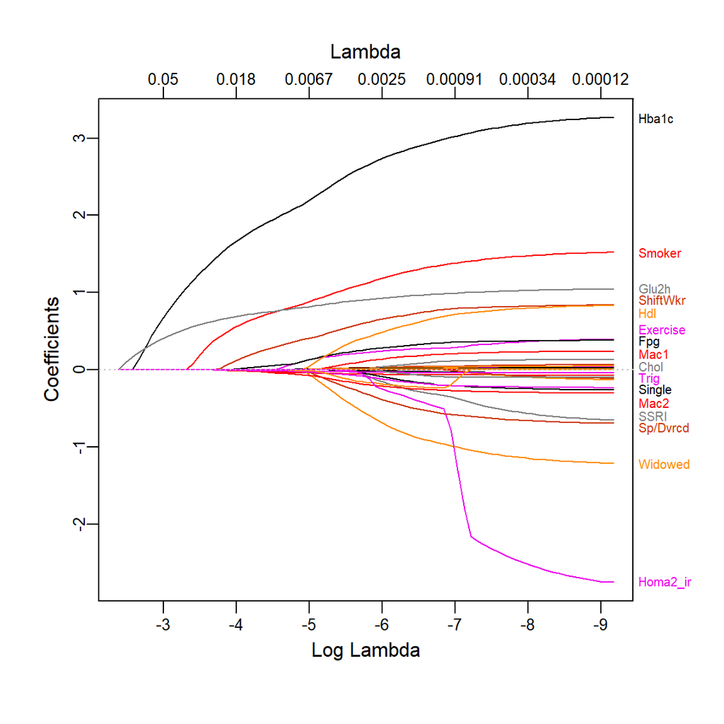

Visualisation of coefficients from LASSO model, with all 33 risk factors included

plotmo::plot_glmnet() to plot a glmnet::glmnet() object

## Step three: select from 16 risk factors + fit model

- LASSO penalisation<sup>1</sup> using 469 with complete data
- 10 fold cross validation was used to maximise AUC
- dotted line denotes max AUC, with two non-zero covariates selected in the model (HbA1c and 2-hour glucose)
- refit without penalisation, with AUC **0.809** (n= 665 patients)
- including T treatment<sup>2</sup>, AUC **0.816**.

[interactive chart not shown]

plotly::ggplotly() to interactively plot a ggplot object

[^1]: Zhao S, Daniela Witten, Ali Shojaie “In Defense of the Indefensible: A Very Naïve Approach to High-Dimensional Inference,” Statistical Science. 36(4), 562-577, (November 2021) https://doi.org/10.1214/20-STS815
[^2]: **T treatment was associated with 40% reduction in diabetes at two years**

## Step four: exploration of interactions

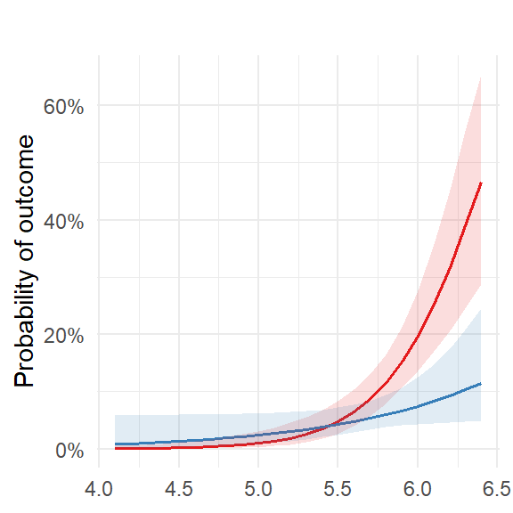

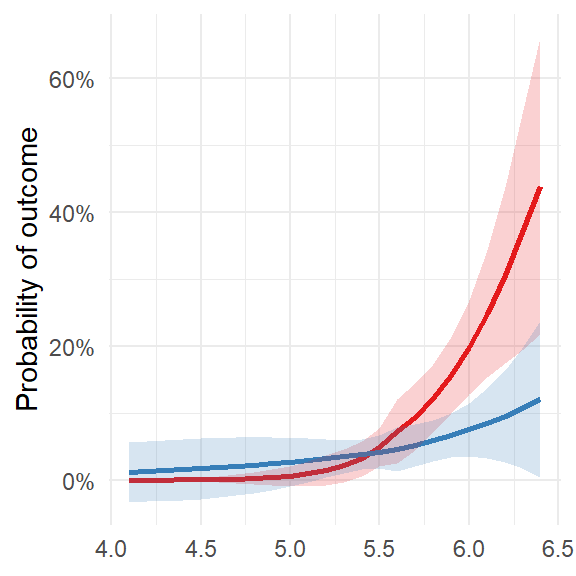

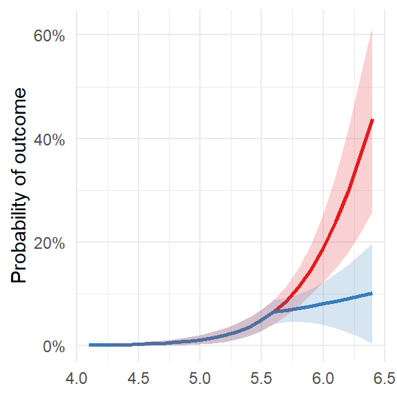

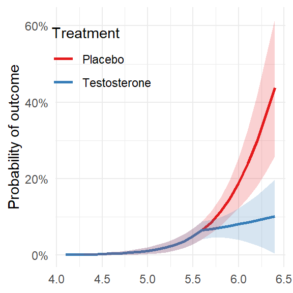

## 3D plot

[interactive chart not shown]

3D plot of the interaction between HbA1c, 2-hr glucose and treatment

plotly::plot_ly() function from the plotly package to create a 3D plot (using `add_surface`)

## Step five: Sensitivity analyses

1. Perform multiple imputation for the model with the 16 risk factors (30 datasets)
2. 10-fold CV using LASSO on each of the 30 datasets
3. Add each covariate back into the base model

## Step six: Model performance (**Discrimination**)

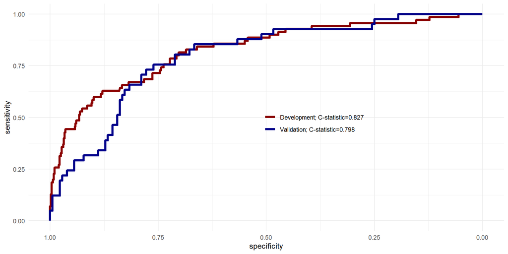

pROC::ggroc() function from the pROC package to plot a ggplot version of ROC curve

## Step seven: Model performance (**Calibration**)

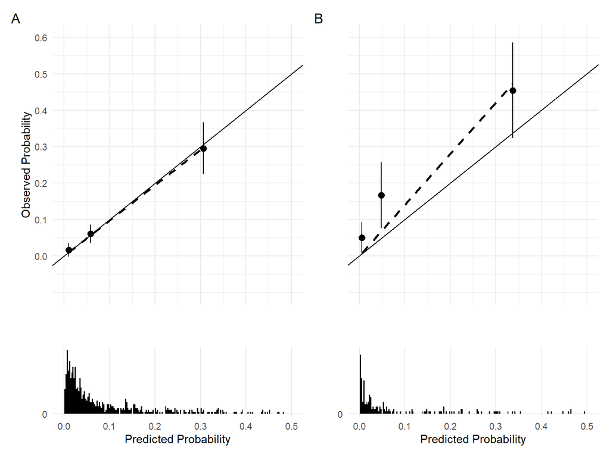

Calibration plot for (A) model development cohort and (B) model validation cohort

## Step eight: Recalibration

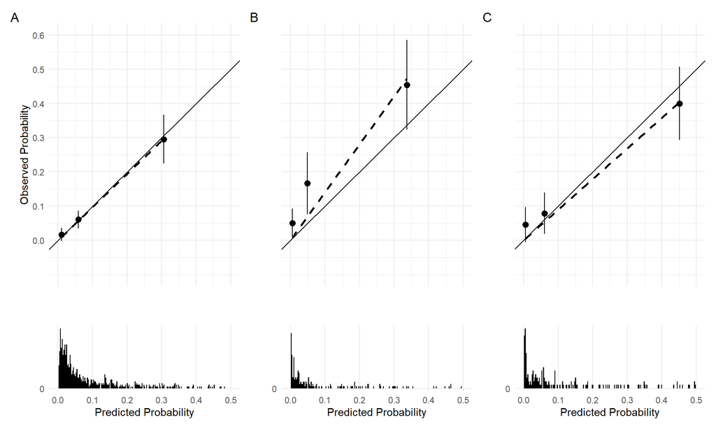

Calibration plot for (A) model development cohort, (B) model validation cohort and (C) for recalibration in the large.

https://clinical-risk-calculators.sydney.edu.au/Nomograms?ToolId=25

# Prediction: lessons learnt

- there are many methods that can be used!
- the importance of data completeness (and the need for sensitivity analyses)
- we found a really interesting interaction, that would not have been detected otherwise!
- its very hard to follow reporting guidelines within journal word limits (33 pages of supplementary materials…)

# Inference example: T4DM Mediation analysis

## Mediation analysis

- tool to disentangle potential causal pathways in data from clinical trials
- T4DM found a 40% reduction in diabetes with testosterone treatment
- also changes in body composition with T treatment (decreased fat mass, increased muscle mass)
- was it the direct effect of testosterone treatment? Or the testosterone-induced changes in body composition?

[figure not shown]

https://academic.oup.com/ejendo/article/189/1/50/7219871

## Reporting of mediation analyses

[figure not shown]

## Methods used

- “parallel” mediation
- counterfactual framework (imputation based approach with robust SE)
- joint mediation model for each outcome
- `medflex` package for mediation analyses
- `mice` for multiple imputation
- reporting criteria

Lange T, Vansteelandt S, Bekaert M. A simple unified approach for estimating natural direct and indirect effects. American Journal of Epidemiology 2012. https://doi.org/10.1093/aje/kwr525

Lange T, Rasmussen M, Thygesen LC. Assessing natural direct and indirect effects through multiple pathways. American Journal of Epidemiology 2013. https://doi.org/10.1093/aje/kwt270

Lange T, Hansen KW, Sørensen R, Galatius S. Applied mediation analyses: A review and tutorial. Epidemiol Health 2017. https://doi.org/10.4178/epih.e2017035

## The causal pathway for T4DM

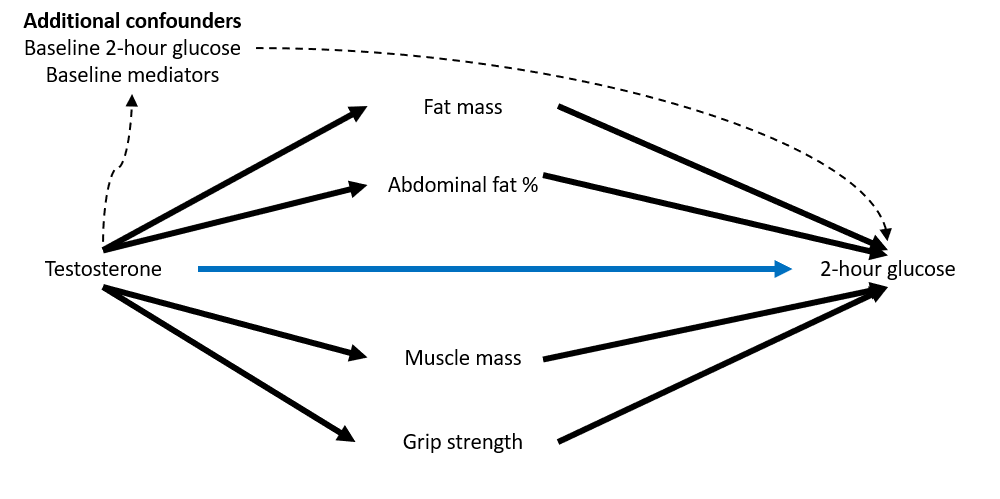

## Mediation results

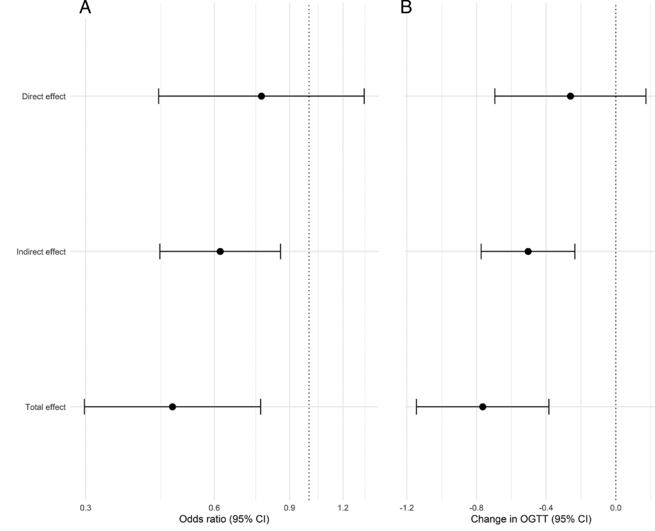

## Sensitivity analyses

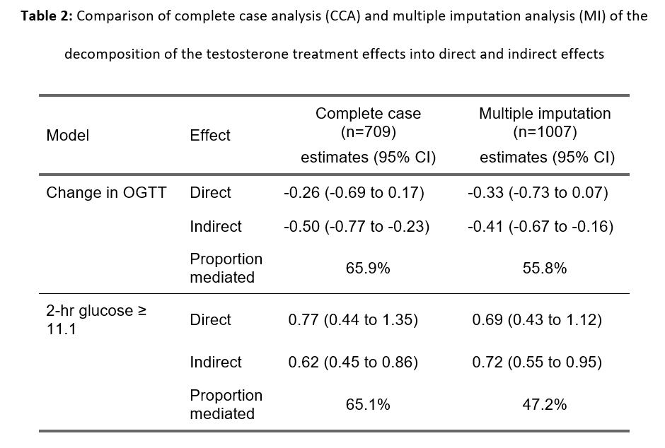

## But which is the primary mediator??

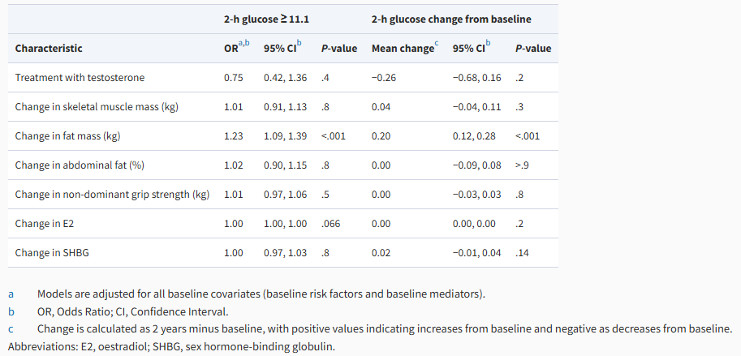

# Conclusions

- first mediation analysis for testosterone treatment
- at least part (but not all) was mediated by changes in fat mass, abdominal fat, skeletal muscle mass, grip strength, SHBG, and E2
- appeared to be driven by changes in fat mass
- future research into other mediation pathways

# Referenced in guidelines!

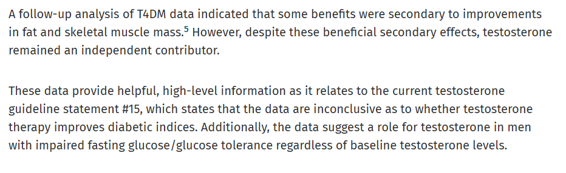

# Next steps

- explore model stability (Riley 2023 https://doi.org/10.1002/bimj.202200302)
- development of risk prediction models within individual patient data meta-analysis project
- challenges of using machine learning for predicion within clinical trials
- explore changing risk factors over the clinical trial, and affects on prediction
- effects of partial clustering on prediction
- inference when there are non-proportional hazards

## **Thank you!**

- questions?
- chat with me kristy.robledo@sydney.edu.au
- Slides available at: https://kristyrobledo.github.io/predictionmodelling_talk/
- Prediction paper code: https://github.com/kristyrobledo/diabetes_riskscore
- Mediation paper code: https://github.com/kristyrobledo/T4DM_mediation_paper